# Bias in the U.S. Prison System

Kunal Srivastava

2022-11-20

## Abstract

In this data exploration, I work with U.S. prison data. This data has been mainly collected from sources like the Census of Jails (COJ) and the National Corrections Reporting Program (NCRP). The data set also includes population estimates and geographic information. I want to explore inequality in this analysis, because I already know the U.S. prison system is broken in terms of fairness. Minorities are prosecuted at a higher rate due to biases. I look to examine 4-5 variables in this data set.

## Section 1: Introduction

Ever since the abolishment of slavery in the 1960’s, America has been on a path of progress to equality and equity as it comes to minorities, and others who are at marginalized disadvantages, like members of the LGBTQ+ community. The data set I explore in the analysis is a record of US Prison Data, in which the goal is to find and display evidence of patterns of inequality. This relates a lot to current social issues in America, where the fight for equality is just as strong. Direct and indirect stakeholders of this data include actual prison inmates, prison staff, the government, and even the U.S. taxpayer, who funds the prisons. In my report, I aim to answer questions like finding statistical discrepancies in quantitative data by race, location, etc.

## Section 2: Data Summary

Looking through the data, I am really interested in the population columns as it comes to race. My idea is to analyze these population columns by race with different methods to see if there are any equality discrepancies. I expect the black population percentage to be higher than most, because I already know that is a current social bias in the U.S. Prison System. In this data set, the total number of observation (entries) was **153811**. Over all the male prisoners over all years, the average percentage of black male prisoners was **63.32%**, the average percentage of latin male prisoners was **31.77%**, and the average percentage of white male prisoners was **44.11%**. These initial values show some clear inequality in that there are much more black men getting incarcerated than other men. As I continue with this analysis, my next idea is to break my discoveries up by geolocation, county, or add in other numerical data from other columns for augmented insights.

## Section 3: Growth of the U.S. Prison Population

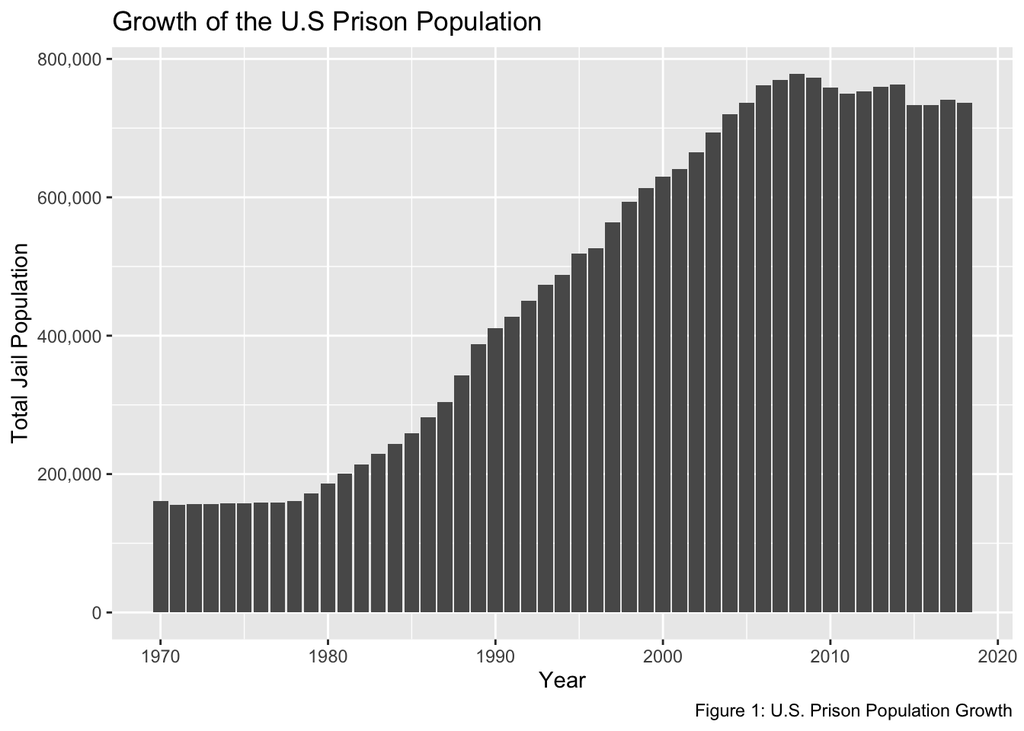

## Section 4: Growth of Prison Population by State

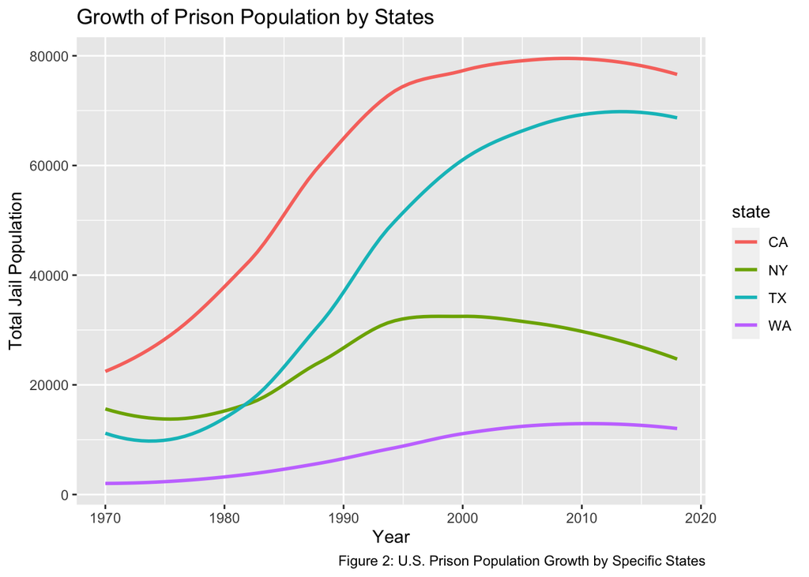

## Section 5: Growth of White Vs. Black Prison Populations

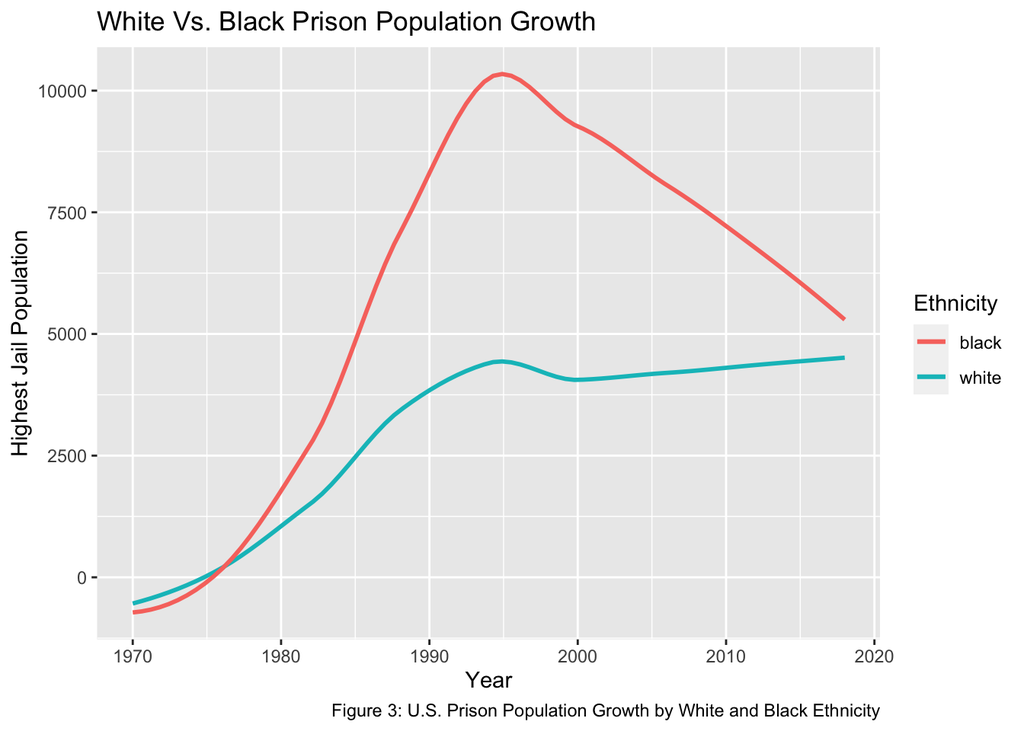

**Have black individuals been imprisoned at a higher rate than white individuals? If so, when?** Yes, black individuals have been imprisoned at a much higher rate than whites, most notably from the years 1980-1995. The visualization shows a dramatic increase, starting in 1980, of blacks being imprisoned. There is a very steep increase for about 15 years, but then I notice a decline in black imprisonment from 1995 all the way to 2017. This is likely equality efforts. Now that I know there is a bias in the prison populations as it comes to race, I will explore geo-locations as it just relates to blacks, in order to see **where** they are disadvantaged.

## Section 6: Black Prison Populations by County in the US.

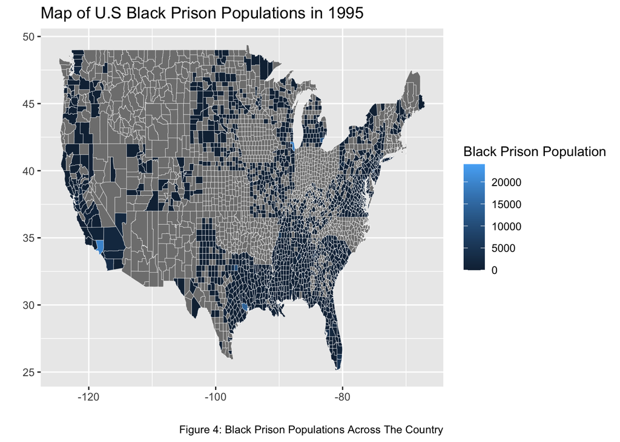